# Many Kinds of Feature Importance

### Setup

We begin by defining a PMF presented in Devroye, Gyorfi, and Lugosi (1997) - Theorem 32.2. This theorem finds its roots in Toussaint (1971): "Note on Optimal Selection of Independent Binary-Valued Features for Pattern Recognition." Toussaint's note is based on Elashoff's 1967 paper "On the choice of variables in classification problems with dichotomous variables."

There exist binary-valued random variables $X_1$, $X_2$, $X_3$, $Y \in \{0, 1\}$ such that $X_1$, $X_2$, and $X_3$ are conditionally independent (given $Y$), and

$L^*(\{1\}) < L^*(\{2\}) < L^*(\{3\})$,

but

$L^*(\{1, 2\}) > L^*(\{1, 3\}) > L^*(\{2, 3\})$.

**PROOF.** Let $P(Y = 1) = 1/2$. Then the joint distribution of $X_1$, $X_2$, $X_3$, $Y$ is specified by the conditional probabilities $P(X_i = 1 \mid Y = 0)$ and $P(X_i = 1 \mid Y = 1)$, $i = 1, 2, 3$. Straightforward calculation shows that the values

$P(X_1 = 1 \mid Y = 0) = 0.1, P(X_1 = 1 \mid Y = 1) = 0.9,$

$P(X_2 = 1 \mid Y = 0) = 0.05, P(X_2 = 1 \mid Y = 1) = 0.8,$

$P(X_3 = 1 \mid Y = 0) = 0.01, P(X_3 = 1 \mid Y = 1) = 0.71$

satisfy the stated inequalities.

*Mike's Note:* It's worth observing the relationships between these three variables and $Y$. As you go from $X_1$ to $X_2$ to $X_3$, they become more useful for prediction when $Y=0$ (specificity). In contrast, they become more useful in reverse order ($X_3$ to $X_2$ to $X_1$) for prediction when $Y=1$ (sensitivity).

### "Straightforward Calculations"

We'd like to store the joint PMF as a data frame. In each row we'll store a possible outcome.

Example: [$X_1 = 0$, $X_2 = 0$, $X_3 = 0$, $Y = 0$, $P(\text{this row})] \implies [0, 0, 0, 0, p]$

The conditional independence of the $X$ covariates given $Y$ allows us to obtain $p$ through simple multiplication:

$\begin{align} P(X_1, X_2, X_3, Y) = &P(X_1, X_2, X_3 | Y) \times P(Y) \\ = &P(X_1|Y) \times P(X_2|Y) \times P(X_3|Y) \times P(Y) \end{align}$

Example:

$\begin{align} P(X_1 = 0, X_2 = 0, X_3 = 0, Y = 0) = &P(X_1=0|Y=0) \; \times\\ &P(X_2=0|Y=0) \; \times\\ &P(X_3=0|Y=0) \; \times\\ &P(Y = 0) \end{align}$

We have all such conditional probabilities (or their complements) specified in the problem statement.

```python
import numpy as np
import pandas as pd
from scipy.stats import entropy
```

```python
# In the following, P(Xj=x|Y=y) is accessed with p_xj_y[y,x].
p_x1_y = np.array([[.9, .1], [.1, .9]])
p_x2_y = np.array([[.95, .05], [.2, .8]])
p_x3_y = np.array([[.99, .01], [.29, .71]])
p_y = np.array([.5, .5])

pmf = np.ones((2**4,5)) * -1

pmf_idx = 0
for x1 in [0,1]:
    for x2 in [0,1]:
        for x3 in [0,1]:
            for y in [0,1]:
                p = p_x1_y[y, x1] * p_x2_y[y, x2] * p_x3_y[y, x3] * p_y[y]
                pmf[pmf_idx, :] = np.array([x1, x2, x3, y, p])
                pmf_idx += 1

pmf = pd.DataFrame(pmf)
pmf.columns = ["X1", "X2", "X3", "Y", "p"]
pmf
```

|  | X1 | X2 | X3 | Y | p |
| --- | --- | --- | --- | --- | --- |
| 0 | 0.0 | 0.0 | 0.0 | 0.0 | 0.423225 |
| 1 | 0.0 | 0.0 | 0.0 | 1.0 | 0.002900 |
| 2 | 0.0 | 0.0 | 1.0 | 0.0 | 0.004275 |
| 3 | 0.0 | 0.0 | 1.0 | 1.0 | 0.007100 |
| 4 | 0.0 | 1.0 | 0.0 | 0.0 | 0.022275 |
| 5 | 0.0 | 1.0 | 0.0 | 1.0 | 0.011600 |
| 6 | 0.0 | 1.0 | 1.0 | 0.0 | 0.000225 |
| 7 | 0.0 | 1.0 | 1.0 | 1.0 | 0.028400 |
| 8 | 1.0 | 0.0 | 0.0 | 0.0 | 0.047025 |
| 9 | 1.0 | 0.0 | 0.0 | 1.0 | 0.026100 |
| 10 | 1.0 | 0.0 | 1.0 | 0.0 | 0.000475 |
| 11 | 1.0 | 0.0 | 1.0 | 1.0 | 0.063900 |
| 12 | 1.0 | 1.0 | 0.0 | 0.0 | 0.002475 |
| 13 | 1.0 | 1.0 | 0.0 | 1.0 | 0.104400 |
| 14 | 1.0 | 1.0 | 1.0 | 0.0 | 0.000025 |
| 15 | 1.0 | 1.0 | 1.0 | 1.0 | 0.255600 |

```python
# Valid PMF? Yep.
pmf['p'].sum()
```

```
0.9999999999999999
```

### Function Definitions

We're going to need a few functions that perform probability calculations.

- Compute Probability of Event from PMF
- Conditional Probability
- Conditional Entropy

```python
# Obtain Probability (any unconditioned event)
def prob(pmf, event):
    # Sum all the p values that correspond to rows satisfying the "event" constraint.
    return pmf[(pmf[list(event.keys())] == pd.Series(event)).all(axis=1)].loc[:,"p"].sum()

# Conditional Probability
def cond_prob(pmf, event, given):
    # Filter the PMF to retain only the rows that satisfy the "given" constraint.
    given_pmf = pmf[(pmf[list(given.keys())] == pd.Series(given)).all(axis=1)]
    # Sum all the p values that correspond to rows satisfying the "given" constraint.
    given_mass = given_pmf.loc[:,"p"].sum()
    # Within the filtered "given" PMF (potentially reduced total rows), sum all the
    # p values that correspond to rows satisfying the "event" constraint.  This is
    # the intersection of the "event" and "given" constraints.
    event_mass = given_pmf[(given_pmf[list(event.keys())] == pd.Series(event)).all(axis=1)].loc[:,"p"].sum()
    # Return ("event" AND "given" / "given")
    return event_mass / given_mass

# Conditional Entropy
# (Note: Takes care of both class 0 and 1.  Supply either "event" for Y value.)
def cond_entropy(pmf, event, given):
    this_cond_prob = cond_prob(pmf, event, given)
    return entropy([this_cond_prob, 1 - this_cond_prob], base=2)
```

### Example Function Usage

```python
# Extract a probability from the PMF.
# Example: Obtain the probability of the first row outcome in the PMF.
event = {'X1': 0.0,
         'X2': 0.0,
         'X3': 0.0,
         'Y': 0.0}
prob(pmf, event)
```

```
0.42322499999999996
```

```python
# Conditional Probability
# Example: Find P(Y=0|X1=0,X2=0,X3=0)
event = {'Y': 0.0}
given = {'X1': 0.0,
         'X2': 0.0,
         'X3': 0.0}
cond_prob(pmf, event, given)
```

```
0.9931944851862716
```

```python
# Conditional Entropy
# Example: Find H(Y|X1=0,X2=0,X3=0)
event = {'Y': 0.0} # Remember: either Y value will work.
given = {'X1': 0.0,
         'X2': 0.0,
         'X3': 0.0}
cond_entropy(pmf, event, given)
```

```
0.0587782426667411
```

### Computing Loss - Best Single Feature

Below we'll find that single-feature classifier performance would rank features in this order: $X_1$, $X_2$, $X_3$.

```python
# Feature 1

# P(Y=0|X1)
p_y_0_x1 = np.zeros(2)
for x1 in [0,1]:
    event = {'Y': 0.0}
    given = {'X1': x1}
    p_y_0_x1[x1] = cond_prob(pmf, event, given)

# P(Y=1|X1)
p_y_1_x1 = np.zeros(2)
for x1 in [0,1]:
    event = {'Y': 1.0}
    given = {'X1': x1}
    p_y_1_x1[x1] = cond_prob(pmf, event, given)

# P(X1)
p_x1 = np.zeros(2)
for x1 in [0,1]:
    event = {'X1': x1}
    p_x1[x1] = prob(pmf, event)

# Which to choose?
p_correct_x1 = np.sum(np.maximum(p_y_0_x1, p_y_1_x1) * p_x1)
print(f"Feature 1 Loss: {(1 - p_correct_x1):.5f}")
```

```
Feature 1 Loss: 0.10000
```

```python
# Feature 2

# P(Y=0|X2)
p_y_0_x2 = np.zeros(2)
for x2 in [0,1]:
    event = {'Y': 0.0}
    given = {'X2': x2}
    p_y_0_x2[x2] = cond_prob(pmf, event, given)

# P(Y=1|X2)
p_y_1_x2 = np.zeros(2)
for x2 in [0,1]:
    event = {'Y': 1.0}
    given = {'X2': x2}
    p_y_1_x2[x2] = cond_prob(pmf, event, given)

# P(X2)
p_x2 = np.zeros(2)
for x2 in [0,1]:
    event = {'X2': x2}
    p_x2[x2] = prob(pmf, event)

# Which to choose?
p_correct_x2 = np.sum(np.maximum(p_y_0_x2, p_y_1_x2) * p_x2)
print(f"Feature 2 Loss: {(1 - p_correct_x2):.5f}")
```

```
Feature 2 Loss: 0.12500
```

```python
# Feature 3

# P(Y=0|X3)
p_y_0_x3 = np.zeros(2)
for x3 in [0,1]:
    event = {'Y': 0.0}
    given = {'X3': x3}
    p_y_0_x3[x3] = cond_prob(pmf, event, given)

# P(Y=1|X3)
p_y_1_x3 = np.zeros(2)
for x3 in [0,1]:
    event = {'Y': 1.0}
    given = {'X3': x3}
    p_y_1_x3[x3] = cond_prob(pmf, event, given)

# P(X3)
p_x3 = np.zeros(2)
for x3 in [0,1]:
    event = {'X3': x3}
    p_x3[x3] = prob(pmf, event)

# Which to choose?
p_correct_x3 = np.sum(np.maximum(p_y_0_x3, p_y_1_x3) * p_x3)
print(f"Feature 3 Loss: {(1 - p_correct_x3):.5f}")
```

```
Feature 3 Loss: 0.15000
```

### Computing Loss - Best Two Features

Below we'll find that two-feature classifier performance would rank features in this order: $\{X_2,X_3\}$, $\{X_1,X_3\}$, $\{X_1,X_2\}$. This is surprising because the best single feature isn't part of the best two-feature classifier! Interestingly, the decision rule is the same for all three two-feature classifiers: if at least one covariate in $\{X_1,X_2,X_3\}$ equals 1, predict class 1.

We need to compute a few probability matrices. $P(Y = 0|X_1,X_2)$ for $X_1 \in \{0,1\}, X_2 \in \{0,1\}$ and $P(Y = 1|X_1,X_2)$ for $X_1 \in \{0,1\}, X_2 \in \{0,1\}$.

```python
# Features 1 and 2

# P(Y=0|X1,X2)
p_y_0_x1_x2 = np.zeros((2,2))
for x1 in [0,1]:
    for x2 in [0,1]:
        event = {'Y': 0.0}
        given = {'X1': x1,
                 'X2': x2}
        p_y_0_x1_x2[x1,x2] = cond_prob(pmf, event, given)

# P(Y=1|X1,X2)
p_y_1_x1_x2 = np.zeros((2,2))
for x1 in [0,1]:
    for x2 in [0,1]:
        event = {'Y': 1.0}
        given = {'X1': x1,
                 'X2': x2}
        p_y_1_x1_x2[x1,x2] = cond_prob(pmf, event, given)

# P(X1,X2)
p_x1_x2 = np.zeros((2,2))
for x1 in [0,1]:
    for x2 in [0,1]:
        event = {'X1': x1,
                 'X2': x2}
        p_x1_x2[x1,x2] = prob(pmf, event)

# Which to choose?
print("For X1 (rows) x X2 (columns) with {0,0} top left, predict as follows:")
print((p_y_1_x1_x2 > p_y_0_x1_x2).astype(int))
p_correct_x1_x2 = np.sum(np.maximum(p_y_0_x1_x2, p_y_1_x1_x2) * p_x1_x2)
print(f"Features 1 & 2 Loss: {(1 - p_correct_x1_x2):.5f}")
```

```
For X1 (rows) x X2 (columns) with {0,0} top left, predict as follows:
[[0 1]
 [1 1]]
Features 1 & 2 Loss: 0.08250
```

```python
# Features 1 and 3

# P(Y=0|X1,X3)
p_y_0_x1_x3 = np.zeros((2,2))
for x1 in [0,1]:
    for x3 in [0,1]:
        event = {'Y': 0.0}
        given = {'X1': x1,
                 'X3': x3}
        p_y_0_x1_x3[x1,x3] = cond_prob(pmf, event, given)

# P(Y=1|X1,X3)
p_y_1_x1_x3 = np.zeros((2,2))
for x1 in [0,1]:
    for x3 in [0,1]:
        event = {'Y': 1.0}
        given = {'X1': x1,
                 'X3': x3}
        p_y_1_x1_x3[x1,x3] = cond_prob(pmf, event, given)

# P(X1,X3)
p_x1_x3 = np.zeros((2,2))
for x1 in [0,1]:
    for x3 in [0,1]:
        event = {'X1': x1,
                 'X3': x3}
        p_x1_x3[x1,x3] = prob(pmf, event)

# Which to choose?
print("For X1 (rows) x X3 (columns) with {0,0} top left, predict as follows:")
print((p_y_1_x1_x3 > p_y_0_x1_x3).astype(int))
p_correct_x1_x3 = np.sum(np.maximum(p_y_0_x1_x3, p_y_1_x1_x3) * p_x1_x3)
print(f"Features 1 & 3 Loss: {(1 - p_correct_x1_x3):.5f}")
```

```
For X1 (rows) x X3 (columns) with {0,0} top left, predict as follows:
[[0 1]
 [1 1]]
Features 1 & 3 Loss: 0.06900
```

```python
# Features 2 and 3

# P(Y=0|X2,X3)
p_y_0_x2_x3 = np.zeros((2,2))
for x2 in [0,1]:
    for x3 in [0,1]:
        event = {'Y': 0.0}
        given = {'X2': x2,
                 'X3': x3}
        p_y_0_x2_x3[x2,x3] = cond_prob(pmf, event, given)

# P(Y=1|X2,X3)
p_y_1_x2_x3 = np.zeros((2,2))
for x2 in [0,1]:
    for x3 in [0,1]:
        event = {'Y': 1.0}
        given = {'X2': x2,
                 'X3': x3}
        p_y_1_x2_x3[x2,x3] = cond_prob(pmf, event, given)

# P(X2,X3)
p_x2_x3 = np.zeros((2,2))
for x2 in [0,1]:
    for x3 in [0,1]:
        event = {'X2': x2,
                 'X3': x3}
        p_x2_x3[x2,x3] = prob(pmf, event)

# Which to choose?
print("For X2 (rows) x X3 (columns) with {0,0} top left, predict as follows:")
print((p_y_1_x2_x3 > p_y_0_x2_x3).astype(int))
p_correct_x2_x3 = np.sum(np.maximum(p_y_0_x2_x3, p_y_1_x2_x3) * p_x2_x3)
print(f"Features 2 & 3 Loss: {(1 - p_correct_x2_x3):.5f}")
```

```
For X2 (rows) x X3 (columns) with {0,0} top left, predict as follows:
[[0 1]
 [1 1]]
Features 2 & 3 Loss: 0.05875
```

Note: All calculations above exactly match the results of Toussaint's 1971 note.

### Plotting Two-Feature Probability Matrices

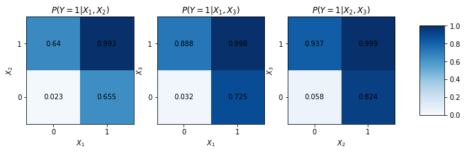

```python
import matplotlib.pyplot as plt
%matplotlib inline

min_max = np.array([[0,0],[1,1]])

fig, (ax1, ax2, ax3) = plt.subplots(1, 3, figsize = (10,6))
# fig.suptitle(r"Two-Feature Binary Classification: $P(Y=1|X_i,X_j)$")
im1 = ax1.imshow(p_y_1_x1_x2, cmap = "Blues", vmin=0, vmax=1, origin = "lower")
ax1.set_yticks([0,1])
ax1.set_xticks([0,1])
ax1.set_title(r'$P(Y=1|X_1,X_2)$')
ax1.set_xlabel(r'$X_1$')
ax1.set_ylabel(r'$X_2$')
for i in [0,1]:
    for j in [0,1]:
        ax1.text(i, j, np.round(p_y_1_x1_x2[i,j],3), horizontalalignment='center', verticalalignment='center')
im2 = ax2.imshow(p_y_1_x1_x3, cmap = "Blues", vmin=0, vmax=1, origin = "lower")
ax2.set_yticks([0,1])
ax2.set_xticks([0,1])
ax2.set_title(r'$P(Y=1|X_1,X_3)$')
ax2.set_xlabel(r'$X_1$')
ax2.set_ylabel(r'$X_3$')
for i in [0,1]:
    for j in [0,1]:
        ax2.text(i, j, np.round(p_y_1_x1_x3[i,j],3), horizontalalignment='center', verticalalignment='center')
im3 = ax3.imshow(p_y_1_x2_x3, cmap = "Blues", vmin=0, vmax=1, origin = "lower")
ax3.set_yticks([0,1])
ax3.set_xticks([0,1])
ax3.set_title(r'$P(Y=1|X_2,X_3)$')
ax3.set_xlabel(r'$X_2$')
ax3.set_ylabel(r'$X_3$')
for i in [0,1]:
    for j in [0,1]:
        ax3.text(i, j, np.round(p_y_1_x2_x3[i,j],3), horizontalalignment='center', verticalalignment='center')
plt.tight_layout()
fig.subplots_adjust(right=0.8)
cbar_ax = fig.add_axes([0.85, 0.35, 0.05, 0.3])
fig.colorbar(im1, cax=cbar_ax)
plt.savefig('prob_plots_discrete.png')
```

The figure above illustrates the common decision rule for all three two-feature classifiers. If any feature equals $1$, predict $\hat{Y}=1$.

### Conditional Entropy

Now we want to examine the various feature combinations in terms of how much uncertainty in $Y$ remains given a set of features in $X$. Conditional entropy averages across all values of $X=x$ (according to their density) the residual uncertainty of $Y$ after knowing $X$.

Conditional Entropy: $H(Y|X) = \sum_{X=x}p(x)\big[-\sum_{Y=y}p(y|x)\log(p(y|x))\big]$

### Conditional Entropy - One Feature

Below we'll find that one-feature conditional entropy would rank features in this order (smallest to largest): $X_1$, $X_2$, $X_3$.

```python
# Feature 1

# H(Y|X1)
h_y_x1 = np.zeros(2)
for x1 in [0,1]:
    event = {'Y': 0.0}
    given = {'X1': x1}
    h_y_x1[x1] = cond_entropy(pmf, event, given)

p_x1 = np.zeros(2)
for x1 in [0,1]:
    event = {'X1': x1}
    p_x1[x1] = prob(pmf, event)

# Compute conditional entropy.
ce_x1 = np.sum(p_x1 * h_y_x1)
print(f"Feature 1 Conditional Entropy: {(ce_x1):.5f}")
```

```
Feature 1 Conditional Entropy: 0.46900
```

```python
# Feature 2

# H(Y|X2)
h_y_x2 = np.zeros(2)
for x2 in [0,1]:
    event = {'Y': 0.0}
    given = {'X2': x2}
    h_y_x2[x2] = cond_entropy(pmf, event, given)

# P(X2)
p_x2 = np.zeros(2)
for x2 in [0,1]:
    event = {'X2': x2}
    p_x2[x2] = prob(pmf, event)

# Compute conditional entropy.
ce_x2 = np.sum(p_x2 * h_y_x2)
print(f"Feature 2 Conditional Entropy: {(ce_x2):.5f}")
```

```
Feature 2 Conditional Entropy: 0.52045
```

```python
# Feature 3

# H(Y=0|X3)
h_y_x3 = np.zeros(2)
for x3 in [0,1]:
    event = {'Y': 0.0}
    given = {'X3': x3}
    h_y_x3[x3] = cond_entropy(pmf, event, given)

# P(X3)
p_x3 = np.zeros(2)
for x3 in [0,1]:
    event = {'X3': x3}
    p_x3[x3] = prob(pmf, event)

# Compute conditional entropy.
ce_x3 = np.sum(p_x3 * h_y_x3)
print(f"Feature 3 Conditional Entropy: {(ce_x3):.5f}")
```

```
Feature 3 Conditional Entropy: 0.53207
```

We really should consider importance in terms of mutual information rather than conditional entropy so that we have a known baseline; otherwise, a scenario could exist in which we don't know the baseline and an uninformative feature ($H(Y)=H(Y|X)$) ranks "least important" rather than "not important." Mutual information equaling 0 makes it clear when a feature is not important.

### Conditional Entropy - Two Features

Below we'll find that two-feature classifier performance measured by conditional entropy would rank features in this order: $\{X_1,X_3\}$, $\{X_1,X_2\}$, $\{X_2,X_3\}$. Unfortunately, this moves our previous winner (as ranked by expected loss) to third place.

```python
# Features 1 and 2

# H(Y|X1,X2)
h_y_x1_x2 = np.zeros((2,2))
for x1 in [0,1]:
    for x2 in [0,1]:
        event = {'Y': 0.0}
        given = {'X1': x1,
                 'X2': x2}
        h_y_x1_x2[x1,x2] = cond_entropy(pmf, event, given)

# P(X1,X2)
p_x1_x2 = np.zeros((2,2))
for x1 in [0,1]:
    for x2 in [0,1]:
        event = {'X1': x1,
                 'X2': x2}
        p_x1_x2[x1,x2] = prob(pmf, event)

# Compute conditional entropy.
ce_x1_x2 = np.sum(p_x1_x2 * h_y_x1_x2)
print(f"Features 1 & 2 Conditional Entropy: {(ce_x1_x2):.5f}")
```

```
Features 1 & 2 Conditional Entropy: 0.27710
```

```python
# Features 1 and 3

# H(Y|X1,X3)
h_y_x1_x3 = np.zeros((2,2))
for x1 in [0,1]:
    for x3 in [0,1]:
        event = {'Y': 0.0}
        given = {'X1': x1,
                 'X3': x3}
        h_y_x1_x3[x1,x3] = cond_entropy(pmf, event, given)

# P(X1,X3)
p_x1_x3 = np.zeros((2,2))
for x1 in [0,1]:
    for x3 in [0,1]:
        event = {'X1': x1,
                 'X3': x3}
        p_x1_x3[x1,x3] = prob(pmf, event)

# Compute conditional entropy.
ce_x1_x3 = np.sum(p_x1_x3 * h_y_x1_x3)
print(f"Features 1 & 3 Conditional Entropy: {(ce_x1_x3):.5f}")
```

```
Features 1 & 3 Conditional Entropy: 0.27132
```

```python
# Features 2 and 3

# H(Y|X2,X3)
h_y_x2_x3 = np.zeros((2,2))
for x2 in [0,1]:
    for x3 in [0,1]:
        event = {'Y': 0.0}
        given = {'X2': x2,
                 'X3': x3}
        h_y_x2_x3[x2,x3] = cond_entropy(pmf, event, given)

# P(X2,X3)
p_x2_x3 = np.zeros((2,2))
for x2 in [0,1]:
    for x3 in [0,1]:
        event = {'X2': x2,
                 'X3': x3}
        p_x2_x3[x2,x3] = prob(pmf, event)

# Compute conditional entropy.
ce_x2_x3 = np.sum(p_x2_x3 * h_y_x2_x3)
print(f"Features 2 & 3 Conditional Entropy: {(ce_x2_x3):.5f}")
```

```
Features 2 & 3 Conditional Entropy: 0.28260
```

### Computing Loss - All Three Features

```python
# Features 1, 2, and 3

# P(Y=0|X1,X2,X3)
p_y_0_x1_x2_x3 = np.zeros((2,2,2))
for x1 in [0,1]:
    for x2 in [0,1]:
        for x3 in [0,1]:
            event = {'Y': 0}
            given = {'X1': x1,
                     'X2': x2,
                     'X3': x3}
            p_y_0_x1_x2_x3[x1, x2, x3] = cond_prob(pmf, event, given)

# P(Y=1|X1,X2,X3)
p_y_1_x1_x2_x3 = np.zeros((2,2,2))
for x1 in [0,1]:
    for x2 in [0,1]:
        for x3 in [0,1]:
            event = {'Y': 1}
            given = {'X1': x1,
                     'X2': x2,
                     'X3': x3}
            p_y_1_x1_x2_x3[x1, x2, x3] = cond_prob(pmf, event, given)

# P(X1,X2,X3)
p_x1_x2_x3 = np.zeros((2,2,2))
for x1 in [0,1]:
    for x2 in [0,1]:
        for x3 in [0,1]:
            event = {'X1': x1,
                     'X2': x2,
                     'X3': x3}
            p_x1_x2_x3[x1, x2, x3] = prob(pmf, event)

# Which to choose?
p_correct_x1_x2_x3 = np.sum(np.maximum(p_y_0_x1_x2_x3, p_y_1_x1_x2_x3) * p_x1_x2_x3)
print(f"Features 1, 2, & 3 Loss: {(1 - p_correct_x1_x2_x3):.5f}")
```

```
Features 1, 2, & 3 Loss: 0.04808
```

### Conditional Entropy - Three Features

```python
# Features 1, 2, and 3

# H(Y|X1,X2,X3)
h_y_x1_x2_x3 = np.zeros((2,2,2))
for x1 in [0,1]:
    for x2 in [0,1]:
        for x3 in [0,1]:
            event = {'Y': 0.0}
            given = {'X1': x1,
                     'X2': x2,
                     'X3': x3}
            h_y_x1_x2_x3[x1,x2,x3] = cond_entropy(pmf, event, given)

# P(X1,X2,X3)
p_x1_x2_x3 = np.zeros((2,2,2))
for x1 in [0,1]:
    for x2 in [0,1]:
        for x3 in [0,1]:
            event = {'X1': x1,
                     'X2': x2,
                     'X3': x3}
            p_x1_x2_x3[x1,x2,x3] = prob(pmf, event)

# Compute conditional entropy.
ce_x1_x2_x3 = np.sum(p_x1_x2_x3 * h_y_x1_x2_x3)
print(f"Features 1, 2, & 3 Conditional Entropy: {(ce_x1_x2_x3):.5f}")
```

```
Features 1, 2, & 3 Conditional Entropy: 0.15935
```

### Causal Features

Here we calculate conditional mutual information of the three covariates: $I(Y,X^{(j)}|X^{(−j)})$. We use the following relationship: $I(Y,X^{(j)}|X^{(−j)}) = H(Y|X^{(-j)}) - H(Y|X)$. Since $H(Y|X)$ is fixed, $H(Y|X^{(-j)})$ drives this ranking which is complementary to our two-feature conditional entropy scores. Specifically, it will highlight an individually important feature by measuring how much unique information it provides about $Y$. We find the features to be most import in this order: $X_1$, $X_3$, $X_2$.

```python
#I(Y,Xj|X-j) = H(Y|X-j) - H(Y|X)
mi_x1_x2x3 = ce_x2_x3 - ce_x1_x2_x3
mi_x2_x1x3 = ce_x1_x3 - ce_x1_x2_x3
mi_x3_x1x2 = ce_x1_x2 - ce_x1_x2_x3

print(f"Feature 1 Conditional Mutual Information: {mi_x1_x2x3:.5f}")
print(f"Feature 2 Conditional Mutual Information: {mi_x2_x1x3:.5f}")
print(f"Feature 3 Conditional Mutual Information: {mi_x3_x1x2:.5f}")
```

```
Feature 1 Conditional Mutual Information: 0.12325
Feature 2 Conditional Mutual Information: 0.11197
Feature 3 Conditional Mutual Information: 0.11775
```

Now we consider the conditional mutual information offered by pairs of features. Which pair provides the most information that we couldn't get from the excluded feature?

```python
#I(Y,Xj|X-j) = H(Y|X-j) - H(Y|X)
mi_x2x3_x1 = ce_x1 - ce_x1_x2_x3
mi_x1x3_x2 = ce_x2 - ce_x1_x2_x3
mi_x1x2_x3 = ce_x3 - ce_x1_x2_x3

print(f"Features 2 & 3 Conditional Mutual Information: {mi_x2x3_x1:.5f}")
print(f"Features 1 & 3 Conditional Mutual Information: {mi_x1x3_x2:.5f}")
print(f"Features 1 & 2 Conditional Mutual Information: {mi_x1x2_x3:.5f}")
```

```
Features 2 & 3 Conditional Mutual Information: 0.30965
Features 1 & 3 Conditional Mutual Information: 0.36111
Features 1 & 2 Conditional Mutual Information: 0.37273
```

### Additive Conditional Mutual Information

We should be able to get $I(Y,X)$ by the chain rule:

$I(Y,X) = I(Y,X_1) + I(Y,X_2|X_1) + I(Y,X_3|X_1,X_2)$

We have all of these quantities so far except $I(Y,X_2|X_1)$.

```python
# First compute I(Y,X1) = H(Y) - H(Y|X1).
h_y = 1
I_y_x1 = h_y - ce_x1

# Second compute I(Y,X2|X1) = H(Y|X1) - H(Y|X1,X2).

# H(Y|X1,X2)
h_y_x1_x2 = np.zeros((2,2))
p_y_0_x1_x2 = np.ones((2,2))
for x1 in [0,1]:
    for x2 in [0,1]:
        event = {'Y': 0.0}
        given = {'X1': x1,
                 'X2': x2}
        h_y_x1_x2[x1,x2] = cond_entropy(pmf, event, given)

# P(X1,X2)
p_x1_x2 = np.zeros((2,2))
for x1 in [0,1]:
    for x2 in [0,1]:
        event = {'X1': x1,
                 'X2': x2}
        p_x1_x2[x1,x2] = prob(pmf, event)

# Compute conditional entropy.
ce_x1_x2 = np.sum(p_x1_x2 * h_y_x1_x2)

# Compute conditional mutual information.
I_y_x2_x1 = ce_x1 - ce_x1_x2

# Third compute I(Y,X3|X1,X2) = H(Y|X1,X2) - H(Y|X1,X2,X3).
I_y_x3_x1x2 = ce_x1_x2 - ce_x1_x2_x3

print(f"Total Mutual Information: {I_y_x1 + I_y_x2_x1 + I_y_x3_x1x2}")
```

```
Total Mutual Information: 0.8406518593821544
```

```python
# Boom...looks good.
1 - ce_x1_x2_x3
```

```
0.8406518593821544
```

### Model-Important Features

A model-important feature is one in which a value change often has a significant impact on the classifier's decision. In this scenario, we wish to consider how swapping a 1 for a 0 or vice versa impacts predictions.

What would this look like?

- If I changed $X^{(j)}$, what would I change it to? It only makes sense to see what other values of $X^{(j)}$ were observed.
- What is the distribution of other values of $X^{(j)}$? What is the expected outcome associated with those other values of $X^{(-j)}$?

Basically, it's exactly what we had before ($I(Y,X^{(j)}|X^{(−j)})$) except we now restrict ourselves to a specific $x^{(-j)}$. Thus, we're going to evaluate $I(Y,X^{(j)}|X^{(−j)}=x^{(-j)})$.

```python
# There are only eight outcomes in X.
x_outcomes = []
for x1 in [0,1]:
    for x2 in [0,1]:
        for x3 in [0,1]:
            x_outcomes.append([x1, x2, x3])
print("Outcomes:")
x_outcomes
```

```
Outcomes:
```

```
[[0, 0, 0],
 [0, 0, 1],
 [0, 1, 0],
 [0, 1, 1],
 [1, 0, 0],
 [1, 0, 1],
 [1, 1, 0],
 [1, 1, 1]]
```

For each setting we can compute a posterior probability that an observation matching each outcome $x$ above is class 1: $P(Y=1|X=x)$.

```python
posterior = (p_y_1_x1_x2_x3 / (p_y_1_x1_x2_x3 + p_y_0_x1_x2_x3)).reshape((8,1))
posterior
```

```
array([[0.00680551],
       [0.62417582],
       [0.34243542],
       [0.99213974],
       [0.35692308],
       [0.99262136],
       [0.97684211],
       [0.9999022 ]])
```

For each setting, we have the MLE $\hat{Y}$.

```python
y_hat = (p_y_1_x1_x2_x3 > p_y_0_x1_x2_x3).astype(int).reshape((8,1))
y_hat
```

```
array([[0],
       [1],
       [0],
       [1],
       [0],
       [1],
       [1],
       [1]])
```

Now consider each outcome in order, evaluating $H(Y|X^{(j)},X^{(-j)}=x^{(-j)})$, and ranking features 1 through 3 by descending conditional entropy.

```python
# H(Y|two of the three: X1,X2,X3)
h_y_x1_x2_x3_local = np.zeros((len(y_hat),4))
i = 0
for x1 in [0,1]:
    for x2 in [0,1]:
        for x3 in [0,1]:
            event_y_0 = {'Y': 0}
            given_x1_x2_x3 = {'X1': x1,
                              'X2': x2,
                              'X3': x3}
            event_x1_0 = {'X1': 0}
            event_x1_1 = {'X1': 1}
            given_x2_x3 = {'X2': x2,
                           'X3': x3}
            event_x2_0 = {'X2': 0}
            event_x2_1 = {'X2': 1}
            given_x1_x3 = {'X1': x1,
                           'X3': x3}
            event_x3_0 = {'X3': 0}
            event_x3_1 = {'X3': 1}
            given_x1_x2 = {'X1': x1,
                           'X2': x2}
            h_y_x1_x2_x3_local[i, 0] = cond_entropy(pmf, event_y_0, given_x1_x2_x3)
            h_y_x1_x2_x3_local[i, 1] = cond_entropy(pmf, event_y_0, given_x2_x3) - (cond_prob(pmf, event_x1_0, given_x2_x3) * cond_entropy(pmf, event_y_0, {**event_x1_0, **given_x2_x3}) + cond_prob(pmf, event_x1_1, given_x2_x3) * cond_entropy(pmf, event_y_0, {**event_x1_1, **given_x2_x3}))
            h_y_x1_x2_x3_local[i, 2] = cond_entropy(pmf, event_y_0, given_x1_x3) - (cond_prob(pmf, event_x2_0, given_x1_x3) * cond_entropy(pmf, event_y_0, {**event_x2_0, **given_x1_x3}) + cond_prob(pmf, event_x2_1, given_x1_x3) * cond_entropy(pmf, event_y_0, {**event_x2_1, **given_x1_x3}))
            h_y_x1_x2_x3_local[i, 3] = cond_entropy(pmf, event_y_0, given_x1_x2) - (cond_prob(pmf, event_x3_0, given_x1_x2) * cond_entropy(pmf, event_y_0, {**event_x3_0, **given_x1_x2}) + cond_prob(pmf, event_x3_1, given_x1_x2) * cond_entropy(pmf, event_y_0, {**event_x3_1, **given_x1_x2}))
            i += 1
```

How to interpret this:

- Look at an outcome in the top row and its corresponding posterior underneath.
- Then find the corresponding row in the table at the bottom.
- The first column represents the conditional entropy $H(Y|x^{(1)},x^{(2)},x^{(3)})$.
- The next three columns represent the conditional mutual information

$$I(Y,X^{(j)}|X^{(-j)}=x^{(-j)}) = H(Y|X^{(-j)}=x^{(-j)}) - H(Y|X^{(j)},X^{(-j)}=x^{(-j)}) \quad \text{for} \; j=1,2,3, \, \text{respectively.}$$

```python
print("Outcomes in X: [X1, X2, X3]")
print(x_outcomes)
```

```
Outcomes in X: [X1, X2, X3]
[[0, 0, 0], [0, 0, 1], [0, 1, 0], [0, 1, 1], [1, 0, 0], [1, 0, 1], [1, 1, 0], [1, 1, 1]]
```

```python
print("Posterior Probability P(Y=1|X)")
print(np.round(posterior,4))
```

```
Posterior Probability P(Y=1|X)
[[0.0068]
 [0.6242]
 [0.3424]
 [0.9921]
 [0.3569]
 [0.9926]
 [0.9768]
 [0.9999]]
```

```python
print("Local Conditional Mutual Information")
print("H(Y|x1,x2,x3) I(Y,X1|x2,x3) I(Y,X2|x1,x3) I(Y,X3|x1,x2)")
print(np.round(h_y_x1_x2_x3_local,4))
```

```
Local Conditional Mutual Information
H(Y|x1,x2,x3) I(Y,X1|x2,x3) I(Y,X2|x1,x3) I(Y,X3|x1,x2)
[[0.0588 0.1319 0.0792 0.0751]
 [0.955  0.1413 0.1884 0.0751]
 [0.9271 0.3272 0.0792 0.4098]
 [0.0662 0.0022 0.1884 0.4098]
 [0.9401 0.1319 0.3723 0.4005]
 [0.0629 0.1413 0.003  0.4005]
 [0.1588 0.3272 0.3723 0.0116]
 [0.0014 0.0022 0.003  0.0116]]
```

The table above is useful for identifying which feature has the largest amount of "unique" information about $Y$ given the values of the other features.

```python
# Let's pick apart the first two rows.
# The first column is H(Y|X1=x1,X2=x2,X3=x3).
# The second column is H(Y|X2=x2,X3=x3) - (P(X1=0|X2=x2,X3=x3)*H(Y|X1=0,X2=x2,X3=x3) +
#                                          P(X1=1|X2=x2,X3=x3)*H(Y|X1=1,X2=x2,X3=x3))
# And so on for columns three and four.
# Row 1 corresponds to [0,0,0]
print(cond_entropy(pmf, {'Y': 0}, {'X1': 0, 'X2': 0, 'X3': 0}))
print(cond_entropy(pmf, {'Y': 0}, {'X2': 0, 'X3': 0}) - (cond_prob(pmf, {'X1': 0}, {'X2': 0, 'X3': 0}) * cond_entropy(pmf, {'Y': 0}, {'X1': 0, 'X2': 0, 'X3': 0}) + cond_prob(pmf, {'X1': 1}, {'X2': 0, 'X3': 0}) * cond_entropy(pmf, {'Y': 1}, {'X1': 1, 'X2': 0, 'X3': 0})))
# Row 2 corresponds to [0,0,1]
print(cond_entropy(pmf, {'Y': 0}, {'X1': 0, 'X2': 0, 'X3': 1}))
print(cond_entropy(pmf, {'Y': 0}, {'X2': 0, 'X3': 1}) - (cond_prob(pmf, {'X1': 0}, {'X2': 0, 'X3': 1}) * cond_entropy(pmf, {'Y': 0}, {'X1': 0, 'X2': 0, 'X3': 1}) + cond_prob(pmf, {'X1': 1}, {'X2': 0, 'X3': 1}) * cond_entropy(pmf, {'Y': 1}, {'X1': 1, 'X2': 0, 'X3': 1})))
```

```
0.0587782426667411
0.1319391734544722
0.9550393021523922
0.1412575109654676
```

### Change in Posterior as Feature Importance

Let's now see how conditional mutual information compares with the local impact a feature has on the posterior for each of the possible outcomes.

```python
p_y_x1_x2_x3_delta = np.zeros((len(y_hat),4))
i = 0
for x1 in [0,1]:
    for x2 in [0,1]:
        for x3 in [0,1]:
            event_y_hat = {'Y': int(np.round(posterior[i]))}
            given_x1_x2_x3 = {'X1': x1,
                              'X2': x2,
                              'X3': x3}
            given_x2_x3 = {'X2': x2,
                           'X3': x3}
            given_x1_x3 = {'X1': x1,
                           'X3': x3}
            given_x1_x2 = {'X1': x1,
                           'X2': x2}
            p_y_x1_x2_x3_delta[i, 0] = cond_prob(pmf, event_y_hat, given_x1_x2_x3)
            p_y_x1_x2_x3_delta[i, 1] = p_y_x1_x2_x3_delta[i, 0] - cond_prob(pmf, event_y_hat, given_x2_x3)
            p_y_x1_x2_x3_delta[i, 2] = p_y_x1_x2_x3_delta[i, 0] - cond_prob(pmf, event_y_hat, given_x1_x3)
            p_y_x1_x2_x3_delta[i, 3] = p_y_x1_x2_x3_delta[i, 0] - cond_prob(pmf, event_y_hat, given_x1_x2)
            i += 1
```

```python
np.set_printoptions(precision=5, suppress = True)
print("Change in Posterior Due to Xj")
print("+ means Xj = xj increases posterior")
print("- means Xj = xj decreases posterior")
print("P(Y^|X)... -P(Y^|x2,x3) -P(Y^|x1,x3) -P(Y^|x1,x2)")
print(np.round(p_y_x1_x2_x3_delta, 5))
```

```
Change in Posterior Due to Xj
+ means Xj = xj increases posterior
- means Xj = xj decreases posterior
P(Y^|X)... -P(Y^|x2,x3) -P(Y^|x1,x3) -P(Y^|x1,x2)
[[ 0.99319  0.05128  0.02472  0.01605]
 [ 0.62418 -0.31312 -0.26332  0.60132]
 [ 0.65756  0.48172 -0.31091  0.29756]
 [ 0.99214 -0.00698  0.10464  0.35214]
 [ 0.64308 -0.29884  0.36808  0.29762]
 [ 0.99262  0.05533 -0.00582  0.33808]
 [ 0.97684  0.15269  0.25184 -0.01626]
 [ 0.9999   0.00078  0.00146  0.0068 ]]
```

```python
# Let's pick apart the first row.  In the first column, we have:
# P(Y=0|X1=0,X2=0,X3=0).  In the second column, we have:
# P(Y=0|X1=0,X2=0,X3=0) - P(Y=0|X2=0,X3=0).  This suggests
# that the posterior increases by .05 with the knowledge X1=0.
print(cond_prob(pmf, {'Y': 0}, {'X1': 0, 'X2': 0, 'X3': 0}))
print(cond_prob(pmf, {'Y': 0}, {'X2': 0, 'X3': 0}))
```

```
0.9931944851862716
0.9419128693039559
```

### Comparing Results to Logistic Regression

I'm undecided on this one, but it would be easy to throw in a logistic regression view of feature importance to demonstrate global feature importance as well as local feature importance / feature contribution for each potential outcome. We'd just need to create a sample that very nearly approximates the PMF constructed at the beginning of this notebook.

```python
# from sklearn.datasets import load_iris
# from sklearn.linear_model import LogisticRegression
# X, y = load_iris(return_X_y=True)
# clf = LogisticRegression(random_state=0).fit(X, y)
# clf.predict(X[:2, :])
# clf.predict_proba(X[:2, :])
# clf.score(X, y)
```

### Gaussian Example Feature Importance Calculations

Let's try to calculate some of the same values we did above for the discrete example.

Here are the two class-conditional distributions we'll use in this example ($i \in \{0,1\}$):

$$f_i = f(x|Y=i) = \mathrm{N}\left( \mu = \begin{bmatrix} i \\ i \\ i \end{bmatrix}, \; \Sigma = \begin{bmatrix} 1-.36i & .504i & 0 \\ .504i & 1-.51i & .035i \\ 0 & .035i & 1-.75i \end{bmatrix} \right)$$

### Prediction Error - Expected Loss

```python
import numpy as np
from scipy.stats import multivariate_normal
from scipy import stats
from scipy.stats import norm
```

```python
# Define the class conditional distributions.
mu0 = np.array([0,0,0])
mu1 = np.array([1, 1, 1])
sd0 = np.array([.8, .7, .5])
rho = np.array(([1,.9,0],
                [.9,1,.1],
                [0,.1,1]))
Sigma0 = np.array(([1,0,0],
                   [0,1,0],
                   [0,0,1]))
Sigma1 = np.zeros(rho.shape)
for i in range(rho.shape[0]):
    for j in range(rho.shape[1]):
        Sigma1[i,j] = sd0[i] * sd0[j] * rho[i,j]
```

```python
# Print the class conditional distribution parameters.
print(f"Class 0 Mean: \n{mu0}")
print(f"Class 0 Covariance: \n{Sigma0}")
print(f"Class 1 Mean: \n{mu1}")
print(f"Class 1 Covariance: \n{Sigma1}")
```

```
Class 0 Mean:
[0 0 0]
Class 0 Covariance:
[[1 0 0]
 [0 1 0]
 [0 0 1]]
Class 1 Mean:
[1 1 1]
Class 1 Covariance:
[[0.64  0.504 0.   ]
 [0.504 0.49  0.035]
 [0.    0.035 0.25 ]]
```

### Single-Feature Loss

```python
# Feature 1:
n=1000000

dim1=0

class0 = np.random.normal(mu0[dim1], Sigma0[dim1,dim1], n)
class1 = np.random.normal(mu1[dim1], Sigma1[dim1,dim1], n)

f_1_error = .5*np.mean(norm.pdf(class0, mu1[dim1], np.sqrt(Sigma1[dim1,dim1])) > norm.pdf(class0, mu0[dim1], np.sqrt(Sigma0[dim1,dim1]))) + .5*np.mean(norm.pdf(class1, mu0[dim1], np.sqrt(Sigma0[dim1,dim1])) > norm.pdf(class1, mu1[dim1], np.sqrt(Sigma1[dim1,dim1])))

print(f"Feature 1 Loss: {f_1_error:.5f}")
```

```
Feature 1 Loss: 0.25886
```

```python
# Feature 2:
# n=100000

dim1=1

class0 = np.random.normal(mu0[dim1], Sigma0[dim1,dim1], n)
class1 = np.random.normal(mu1[dim1], Sigma1[dim1,dim1], n)

f_2_error = .5*np.mean(norm.pdf(class0, mu1[dim1], np.sqrt(Sigma1[dim1,dim1])) > norm.pdf(class0, mu0[dim1], np.sqrt(Sigma0[dim1,dim1]))) + .5*np.mean(norm.pdf(class1, mu0[dim1], np.sqrt(Sigma0[dim1,dim1])) > norm.pdf(class1, mu1[dim1], np.sqrt(Sigma1[dim1,dim1])))

print(f"Feature 2 Loss: {f_2_error:.5f}")
```

```
Feature 2 Loss: 0.22767
```

```python
# Feature 3:
# n=100000

dim1=2

class0 = np.random.normal(mu0[dim1], Sigma0[dim1,dim1], n)
class1 = np.random.normal(mu1[dim1], Sigma1[dim1,dim1], n)

f_3_error = .5*np.mean(norm.pdf(class0, mu1[dim1], np.sqrt(Sigma1[dim1,dim1])) > norm.pdf(class0, mu0[dim1], np.sqrt(Sigma0[dim1,dim1]))) + .5*np.mean(norm.pdf(class1, mu0[dim1], np.sqrt(Sigma0[dim1,dim1])) > norm.pdf(class1, mu1[dim1], np.sqrt(Sigma1[dim1,dim1])))

print(f"Feature 3 Loss: {f_3_error:.5f}")
```

```
Feature 3 Loss: 0.17353
```

### Two-Feature Loss

```python
# Features 1 and 2:
# n=100000

dim1=0
dim2=1

class0 = np.random.multivariate_normal(mu0[[dim1,dim2]], Sigma0[np.ix_([dim1,dim2], [dim1,dim2])], n)
class1 = np.random.multivariate_normal(mu1[[dim1,dim2]], Sigma1[np.ix_([dim1,dim2], [dim1,dim2])], n)

f_1_2_error = .5*np.mean(multivariate_normal.pdf(class0, mean=mu1[[dim1,dim2]], cov=Sigma1[np.ix_([dim1,dim2], [dim1,dim2])]) > multivariate_normal.pdf(class0, mean=mu0[[dim1,dim2]], cov=Sigma0[np.ix_([dim1,dim2], [dim1,dim2])])) + .5*np.mean(multivariate_normal.pdf(class1, mean=mu0[[dim1,dim2]], cov=Sigma0[np.ix_([dim1,dim2], [dim1,dim2])]) > multivariate_normal.pdf(class1, mean=mu1[[dim1,dim2]], cov=Sigma1[np.ix_([dim1,dim2], [dim1,dim2])]))

print(f"Features 1 and 2 Loss: {f_1_2_error:.5f}")
```

```
Features 1 and 2 Loss: 0.14126
```

```python
# Features 1 and 3:
# n=100000

dim1=0
dim2=2

class0 = np.random.multivariate_normal(mu0[[dim1,dim2]], Sigma0[np.ix_([dim1,dim2], [dim1,dim2])], n)
class1 = np.random.multivariate_normal(mu1[[dim1,dim2]], Sigma1[np.ix_([dim1,dim2], [dim1,dim2])], n)

f_1_3_error = .5*np.mean(multivariate_normal.pdf(class0, mean=mu1[[dim1,dim2]], cov=Sigma1[np.ix_([dim1,dim2], [dim1,dim2])]) > multivariate_normal.pdf(class0, mean=mu0[[dim1,dim2]], cov=Sigma0[np.ix_([dim1,dim2], [dim1,dim2])])) + .5*np.mean(multivariate_normal.pdf(class1, mean=mu0[[dim1,dim2]], cov=Sigma0[np.ix_([dim1,dim2], [dim1,dim2])]) > multivariate_normal.pdf(class1, mean=mu1[[dim1,dim2]], cov=Sigma1[np.ix_([dim1,dim2], [dim1,dim2])]))

print(f"Features 1 and 3 Loss: {f_1_3_error:.5f}")
```

```
Features 1 and 3 Loss: 0.16999
```

```python
# Features 2 and 3:
# n=100000

dim1=1
dim2=2

class0 = np.random.multivariate_normal(mu0[[dim1,dim2]], Sigma0[np.ix_([dim1,dim2], [dim1,dim2])], n)
class1 = np.random.multivariate_normal(mu1[[dim1,dim2]], Sigma1[np.ix_([dim1,dim2], [dim1,dim2])], n)

f_2_3_error = .5*np.mean(multivariate_normal.pdf(class0, mean=mu1[[dim1,dim2]], cov=Sigma1[np.ix_([dim1,dim2], [dim1,dim2])]) > multivariate_normal.pdf(class0, mean=mu0[[dim1,dim2]], cov=Sigma0[np.ix_([dim1,dim2], [dim1,dim2])])) + .5*np.mean(multivariate_normal.pdf(class1, mean=mu0[[dim1,dim2]], cov=Sigma0[np.ix_([dim1,dim2], [dim1,dim2])]) > multivariate_normal.pdf(class1, mean=mu1[[dim1,dim2]], cov=Sigma1[np.ix_([dim1,dim2], [dim1,dim2])]))

print(f"Features 2 and 3 Loss: {f_2_3_error:.5f}")
```

```
Features 2 and 3 Loss: 0.16089
```

```python
# Features 1, 2, and 3:

# n=100000

class0 = np.random.multivariate_normal(mu0, Sigma0, n)
class1 = np.random.multivariate_normal(mu1, Sigma1, n)

f_1_2_3_error = .5*np.mean(multivariate_normal.pdf(class0, mean=mu1, cov=Sigma1) > multivariate_normal.pdf(class0, mean=mu0, cov=Sigma0)) + .5*np.mean(multivariate_normal.pdf(class1, mean=mu0, cov=Sigma0) > multivariate_normal.pdf(class1, mean=mu1, cov=Sigma1))

print(f"Features 1, 2, and 3 Loss: {f_1_2_3_error:.5f}")
```

```
Features 1, 2, and 3 Loss: 0.08759
```

### Plotting Two-Feature Probability Surfaces

```python
# Create a probability mesh Z_i_j over a range of Xi and Xj that
# conveys P(Y=1|Xi,Xj) for all combinations of i and j.

dim_lims = 3

dim1=0
dim2=1

this_mu0 = mu0[[dim1,dim2]]
this_Sigma0 = Sigma0[np.ix_([dim1,dim2], [dim1,dim2])]
this_mu1 = mu1[[dim1,dim2]]
this_Sigma1 = Sigma1[np.ix_([dim1,dim2], [dim1,dim2])]

N = 60
X = np.linspace(-dim_lims, dim_lims, N)
Y = np.linspace(-dim_lims, dim_lims, N)
X, Y = np.meshgrid(X, Y)
Z = np.zeros(X.shape)
for i in range(X.shape[0]):
    for j in range(X.shape[1]):
        Z[i,j] = multivariate_normal.pdf([X[i,j],Y[i,j]], this_mu1, this_Sigma1) / (multivariate_normal.pdf([X[i,j],Y[i,j]], this_mu1, this_Sigma1) + multivariate_normal.pdf([X[i,j],Y[i,j]], this_mu0, this_Sigma0))
Z_1_2 = Z

dim1=0
dim2=2

this_mu0 = mu0[[dim1,dim2]]
this_Sigma0 = Sigma0[np.ix_([dim1,dim2], [dim1,dim2])]
this_mu1 = mu1[[dim1,dim2]]
this_Sigma1 = Sigma1[np.ix_([dim1,dim2], [dim1,dim2])]

N = 60
X = np.linspace(-dim_lims, dim_lims, N)
Y = np.linspace(-dim_lims, dim_lims, N)
X, Y = np.meshgrid(X, Y)
Z = np.zeros(X.shape)
for i in range(X.shape[0]):
    for j in range(X.shape[1]):
        Z[i,j] = multivariate_normal.pdf([X[i,j],Y[i,j]], this_mu1, this_Sigma1) / (multivariate_normal.pdf([X[i,j],Y[i,j]], this_mu1, this_Sigma1) + multivariate_normal.pdf([X[i,j],Y[i,j]], this_mu0, this_Sigma0))
Z_1_3 = Z

dim1=1
dim2=2

this_mu0 = mu0[[dim1,dim2]]
this_Sigma0 = Sigma0[np.ix_([dim1,dim2], [dim1,dim2])]
this_mu1 = mu1[[dim1,dim2]]
this_Sigma1 = Sigma1[np.ix_([dim1,dim2], [dim1,dim2])]

N = 60
X = np.linspace(-dim_lims, dim_lims, N)
Y = np.linspace(-dim_lims, dim_lims, N)
X, Y = np.meshgrid(X, Y)
Z = np.zeros(X.shape)
for i in range(X.shape[0]):
    for j in range(X.shape[1]):
        Z[i,j] = multivariate_normal.pdf([X[i,j],Y[i,j]], this_mu1, this_Sigma1) / (multivariate_normal.pdf([X[i,j],Y[i,j]], this_mu1, this_Sigma1) + multivariate_normal.pdf([X[i,j],Y[i,j]], this_mu0, this_Sigma0))
Z_2_3 = Z
```

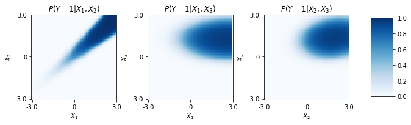

```python
# Produce the two-feature posterior probability plots.
import matplotlib.pyplot as plt
%matplotlib inline

fig, (ax1, ax2, ax3) = plt.subplots(1, 3, figsize = (10,6))
im1 = ax1.imshow(Z_1_2, cmap = "Blues", vmin=0, vmax=1, origin = "lower")
ax1.set_yticks([0,len(Y)/2,len(Y)])
ax1.set_yticklabels([np.min(Y),0,np.max(Y)])
ax1.set_xticks([0,len(X)/2,len(X)])
ax1.set_xticklabels([np.min(X),0,np.max(X)])
ax1.set_title(r'$P(Y=1|X_1,X_2)$')
ax1.set_xlabel(r'$X_1$')
ax1.set_ylabel(r'$X_2$')
im2 = ax2.imshow(Z_1_3, cmap = "Blues", vmin=0, vmax=1, origin = "lower")
ax2.set_yticks([0,len(Y)/2,len(Y)])
ax2.set_yticklabels([np.min(Y),0,np.max(Y)])
ax2.set_xticks([0,len(X)/2,len(X)])
ax2.set_xticklabels([np.min(X),0,np.max(X)])
ax2.set_title(r'$P(Y=1|X_1,X_3)$')
ax2.set_xlabel(r'$X_1$')
ax2.set_ylabel(r'$X_3$')
im3 = ax3.imshow(Z_2_3, cmap = "Blues", vmin=0, vmax=1, origin = "lower")
ax3.set_yticks([0,len(Y)/2,len(Y)])
ax3.set_yticklabels([np.min(Y),0,np.max(Y)])
ax3.set_xticks([0,len(X)/2,len(X)])
ax3.set_xticklabels([np.min(X),0,np.max(X)])
ax3.set_title(r'$P(Y=1|X_2,X_3)$')
ax3.set_xlabel(r'$X_2$')
ax3.set_ylabel(r'$X_3$')
plt.tight_layout()
fig.subplots_adjust(right=0.8)
cbar_ax = fig.add_axes([0.85, 0.35, 0.05, 0.3])
fig.colorbar(im1, cax=cbar_ax)
plt.savefig('prob_plots_gaussian.png')
```

### Conditional Entropy

```python
# Compute true conditional entropy.
import numpy as np
from scipy import integrate
from scipy.stats import multivariate_normal

def calc_H_X(mean0, mean1, cov0, cov1):

    # H_X = multidimensional integral on the sum of pi_0 * pdf0(x) + pi_1 * pdf1(x)
    def integrand(*args):
        rv0 = multivariate_normal(mean=args[-4], cov=args[-2])
        rv1 = multivariate_normal(mean=args[-3], cov=args[-1])
        f_x = .5*rv1.pdf(args[:-4]) + .5*rv0.pdf(args[:-4])
        return -f_x*np.log(f_x) / np.log(2.0)

    sd0 = np.sqrt(np.diag(cov0))
    sd1 = np.sqrt(np.diag(cov1))
    mins = np.min([mean0 - 4*sd0, mean1 - 4*sd1], axis = 0)
    maxes = np.max([mean0 + 4*sd0, mean1 + 4*sd1], axis = 0)
    limits = np.vstack((mins, maxes)).T

    res, err = integrate.nquad(integrand, limits, args=(mean0, mean1, cov0, cov1))

    return res

def calc_H_X_Y(cov0, cov1):

    # H_XY = D / 2 * (1 + np.log(2 * np.pi)) + 1 / 2 * np.log(np.linalg.det(cov))
    # Here we assume pi_0 = pi_1 = .5 and get a weighted average of H_X_Y_(0/1).
    D = cov0.shape[0]
    H_X_Y_0 = D / 2 * (1 + np.log(2 * np.pi)) + 1 / 2 * np.log(np.linalg.det(cov0))
    H_X_Y_1 = D / 2 * (1 + np.log(2 * np.pi)) + 1 / 2 * np.log(np.linalg.det(cov1))

    return (.5 * H_X_Y_0 + .5 * H_X_Y_1) / np.log(2.0)
```

```python
# For testing with simple class conditionals...
# mean0 = np.zeros(3)
# mean1 = np.ones(3)
# cov0 = np.eye(3)
# cov1 = np.eye(3)
```

```python
# Features 1, 2, and 3:

mean0 = mu0
mean1 = mu1
cov0 = Sigma0
cov1 = Sigma1

H_Y = -(2 * .5*np.log(.5)) / np.log(2.0)
H_X = calc_H_X(mean0, mean1, cov0, cov1)
H_X_Y = calc_H_X_Y(cov0, cov1)

H_Y_X_1_2_3 = H_Y - H_X + H_X_Y
print(f"Conditional Entropy (Features 1, 2, and 3): {H_Y_X_1_2_3}")
```

```
Conditional Entropy (Features 1, 2, and 3): 0.30570061625021516
```

```python
# Features 1 and 2:

dim1=0
dim2=1

mean0 = mu0[[dim1,dim2]]
mean1 = mu1[[dim1,dim2]]
cov0 = Sigma0[np.ix_([dim1,dim2], [dim1,dim2])]
cov1 = Sigma1[np.ix_([dim1,dim2], [dim1,dim2])]

H_Y = -(2 * .5*np.log(.5)) / np.log(2.0)
H_X = calc_H_X(mean0, mean1, cov0, cov1)
H_X_Y = calc_H_X_Y(cov0, cov1)

H_Y_X_1_2 = H_Y - H_X + H_X_Y
print(f"Conditional Entropy (Features 1 and 2): {H_Y_X_1_2}")
```

```
Conditional Entropy (Features 1 and 2): 0.4511109157368529
```

```python
# Features 1 and 3:

dim1=0
dim2=2

mean0 = mu0[[dim1,dim2]]
mean1 = mu1[[dim1,dim2]]
cov0 = Sigma0[np.ix_([dim1,dim2], [dim1,dim2])]
cov1 = Sigma1[np.ix_([dim1,dim2], [dim1,dim2])]

H_Y = -(2 * .5*np.log(.5)) / np.log(2.0)
H_X = calc_H_X(mean0, mean1, cov0, cov1)
H_X_Y = calc_H_X_Y(cov0, cov1)

H_Y_X_1_3 = H_Y - H_X + H_X_Y
print(f"Conditional Entropy (Features 1 and 3): {H_Y_X_1_3}")
```

```
Conditional Entropy (Features 1 and 3): 0.5446607422045537
```

```python
# Features 2 and 3:

dim1=1
dim2=2

mean0 = mu0[[dim1,dim2]]
mean1 = mu1[[dim1,dim2]]
cov0 = Sigma0[np.ix_([dim1,dim2], [dim1,dim2])]
cov1 = Sigma1[np.ix_([dim1,dim2], [dim1,dim2])]

H_Y = -(2 * .5*np.log(.5)) / np.log(2.0)
H_X = calc_H_X(mean0, mean1, cov0, cov1)
H_X_Y = calc_H_X_Y(cov0, cov1)

H_Y_X_2_3 = H_Y - H_X + H_X_Y
print(f"Conditional Entropy (Features 2 and 3): {H_Y_X_2_3}")
```

```
Conditional Entropy (Features 2 and 3): 0.5250377971688396
```

```python
# Create one-dimensional conditional entropy calculation function for the gaussian example.
from scipy.stats import norm
from scipy.integrate import quad

def calc_H_Y_Xj(mean0, mean1, cov0, cov1, j):

    sd0 = np.sqrt(cov0[j,j])
    sd1 = np.sqrt(cov1[j,j])
    min_x = np.min([mean0[j] - 4*sd0, mean1[j] - 4*sd1])
    max_x = np.max([mean0[j] + 4*sd0, mean1[j] + 4*sd1])

    def func(x):
        p = 0.5 * norm.pdf(x, mean0[j], sd0) + 0.5 * norm.pdf(x, mean1[j], sd1)
        return -p * np.log(p) / np.log(2.0)

    H_X = quad(func, min_x, max_x)
    # H_XY = np.log(sigma*np.sqrt(2*np.pi*np.e))
    # H_XY = np.log(sigma) + .5*(1 + np.log(2*np.pi))
    # We need a weighted sum of two H_XY where weights are .5.
    # H_XY = .5*(np.log(sd0) + np.log(sd1)) + .5*(1 + np.log(2*np.pi))
    H_XY = (.5*(np.log(sd0) + np.log(sd1)) + .5*(1 + np.log(2*np.pi))) / np.log(2.0)
    H_Y = 1
    # I_XY = H_X - H_XY = H_Y - H_YX
    return H_Y - H_X[0] + H_XY
```

```python
# Compute H(Y|Xj) for each individual feature.
H_Y_X_1 = calc_H_Y_Xj(mu0, mu1, Sigma0, Sigma1, 0)
H_Y_X_2 = calc_H_Y_Xj(mu0, mu1, Sigma0, Sigma1, 1)
H_Y_X_3 = calc_H_Y_Xj(mu0, mu1, Sigma0, Sigma1, 2)
print(f"Conditional Entropy (Feature 1): {H_Y_X_1:.3f}")
print(f"Conditional Entropy (Feature 2): {H_Y_X_2:.3f}")
print(f"Conditional Entropy (Feature 3): {H_Y_X_3:.3f}")
```

```
Conditional Entropy (Feature 1): 0.799
Conditional Entropy (Feature 2): 0.769
Conditional Entropy (Feature 3): 0.677
```

### Conditional Mutual Information

```python
# Now use the H_Y_X_all minus various H_Y_X_subsets to get I(Y,Xs|Xnots).
I_Y_X1_X2X3 = H_Y_X_2_3 - H_Y_X_1_2_3
I_Y_X2_X1X3 = H_Y_X_1_3 - H_Y_X_1_2_3
I_Y_X3_X1X2 = H_Y_X_1_2 - H_Y_X_1_2_3
I_Y_X1X2_X3 = H_Y_X_3 - H_Y_X_1_2_3
I_Y_X1X3_X2 = H_Y_X_2 - H_Y_X_1_2_3
I_Y_X2X3_X1 = H_Y_X_1 - H_Y_X_1_2_3
print(f"Conditional Mutual Information: I(Y,X1|X2,X3): {I_Y_X1_X2X3:.3f}")
print(f"Conditional Mutual Information: I(Y,X2|X1,X3): {I_Y_X2_X1X3:.3f}")
print(f"Conditional Mutual Information: I(Y,X3|X1,X2): {I_Y_X3_X1X2:.3f}")
print(f"Conditional Mutual Information: I(Y,(X1,X2)|X3): {I_Y_X1X2_X3:.3f}")
print(f"Conditional Mutual Information: I(Y,(X1,X3)|X2): {I_Y_X1X3_X2:.3f}")
print(f"Conditional Mutual Information: I(Y,(X2,X3)|X1): {I_Y_X2X3_X1:.3f}")
print(f"Total Mutual Information: I(Y,(X1,X2,X3)): {1 - H_Y_X_1_2_3:.3f}")
```

```
Conditional Mutual Information: I(Y,X1|X2,X3): 0.219
Conditional Mutual Information: I(Y,X2|X1,X3): 0.239
Conditional Mutual Information: I(Y,X3|X1,X2): 0.145
Conditional Mutual Information: I(Y,(X1,X2)|X3): 0.372
Conditional Mutual Information: I(Y,(X1,X3)|X2): 0.463
Conditional Mutual Information: I(Y,(X2,X3)|X1): 0.494
Total Mutual Information: I(Y,(X1,X2,X3)): 0.694
```